# T2 - Exercicis de les diapositives

## Exercici 16

Visualitzarem les dades en una gràfica lineal, semilog i loglog:

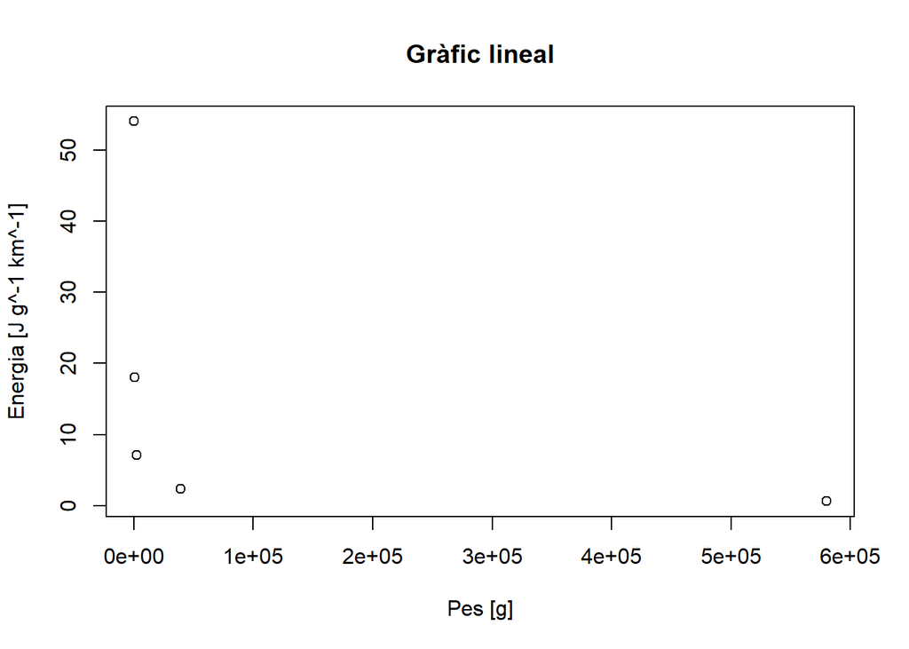

```r
M = c(21, 384, 2.6e3, 3.9e4, 5.8e5)
E = c(54, 18, 7.1, 2.4, 0.63)
plot(M, E, xlab="Pes [g]", ylab="Energia [J g^-1 km^-1]",
     main="Gràfic lineal")
```

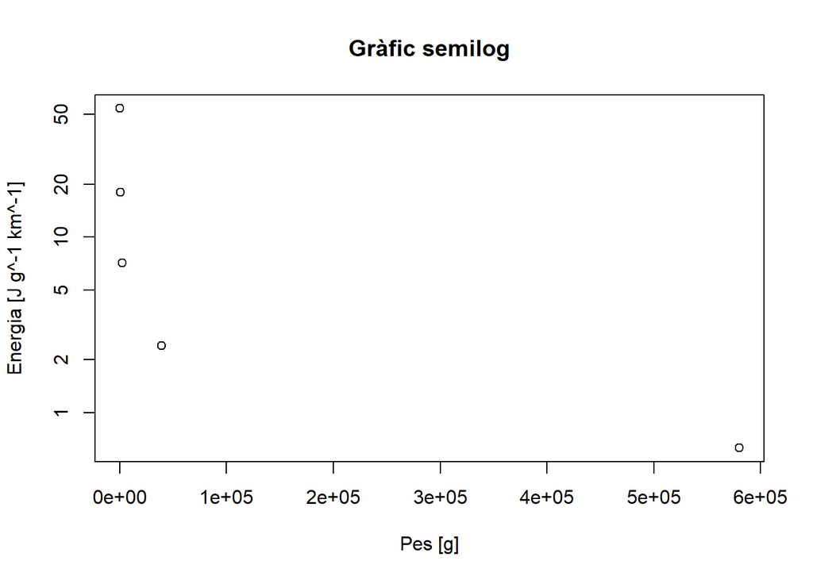

```r
plot(M, E, xlab="Pes [g]", ylab="Energia [J g^-1 km^-1]",
     main="Gràfic semilog", log="y")
```

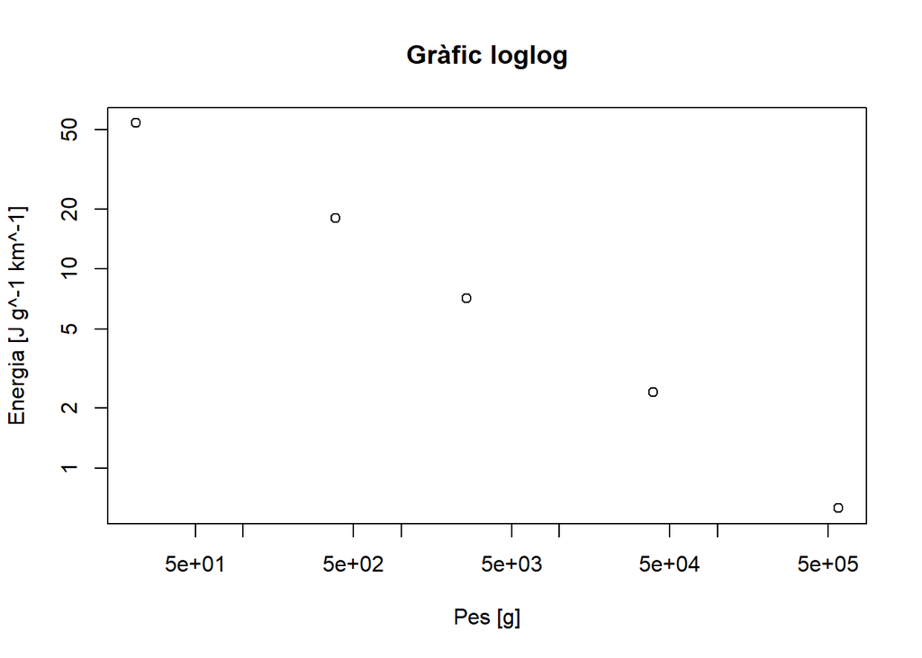

```r
plot(M, E, xlab="Pes [g]", ylab="Energia [J g^-1 km^-1]",
     main="Gràfic loglog", log="xy")
```

Novament, sembla ser potencial. Podem calcular els tres models lineals i comparar el criteri de bondat d’ajust R^2 per comprovar, numèricament, quin és el millor model:

```r
model_lineal = lm(E ~ M)
model_semilog = lm(log10(E) ~ M)
model_loglog = lm(log10(E) ~ log10(M))
# i els mostram per pantalla:
summary(model_lineal); summary(model_semilog); summary(model_loglog);
```

```
##
## Call:
## lm(formula = E ~ M)
##
## Residuals:
##       1       2       3       4       5
##  32.928  -3.058 -13.875 -17.216   1.221
##
## Coefficients:
##               Estimate Std. Error t value Pr(>|t|)
## (Intercept)  2.107e+01  1.170e+01   1.801    0.170
## M           -3.735e-05  4.502e-05  -0.830    0.468
##
## Residual standard error: 22.98 on 3 degrees of freedom
## Multiple R-squared:  0.1866, Adjusted R-squared:  -0.08449
## F-statistic: 0.6884 on 1 and 3 DF,  p-value: 0.4676
```

```
##
## Call:
## lm(formula = log10(E) ~ M)
##
## Residuals:
##        1        2        3        4        5
##  0.64288  0.16659 -0.23233 -0.61973  0.04258
##
## Coefficients:
##               Estimate Std. Error t value Pr(>|t|)
## (Intercept)  1.090e+00  2.760e-01   3.948    0.029 *
## M           -2.298e-06  1.062e-06  -2.165    0.119
## ---
## Signif. codes:  0 '***' 0.001 '**' 0.01 '*' 0.05 '.' 0.1 ' ' 1
##
## Residual standard error: 0.5419 on 3 degrees of freedom
## Multiple R-squared:  0.6097, Adjusted R-squared:  0.4795
## F-statistic: 4.686 on 1 and 3 DF,  p-value: 0.1191
```

```
##
## Call:
## lm(formula = log10(E) ~ log10(M))
##
## Residuals:
##         1         2         3         4         5
## -0.034085  0.037890 -0.004744  0.035880 -0.034941
##
## Coefficients:
##             Estimate Std. Error t value Pr(>|t|)
## (Intercept)  2.34172    0.04624   50.65  1.7e-05 ***
## log10(M)    -0.43506    0.01199  -36.29  4.6e-05 ***
## ---
## Signif. codes:  0 '***' 0.001 '**' 0.01 '*' 0.05 '.' 0.1 ' ' 1
##
## Residual standard error: 0.04134 on 3 degrees of freedom
## Multiple R-squared:  0.9977, Adjusted R-squared:  0.997
## F-statistic:  1317 on 1 and 3 DF,  p-value: 4.601e-05
```

El millor model és, per tant, el model potencial.

- Apartat b)

La relació donada és
$$\log(E) = 2.341 - 0.435 \log(M) \Rightarrow E = 10^{2.341} \cdot M^{-0.435}$$

- Apartat c)

Calculem, segons el nostre model, l’energia que necessita una persona de 75 Kg per transportar 1 gram de massa corporal durant 1 km:

```r
M_persona = 75e3
E_persona = 10^2.341 * M_persona^-0.435
```

Una persona requereix de 1.6609186 J g^-1 km^-1. Per transportar 1 km el seu pes (que són 75000 grams), necessitarà:

```r
E_persona_1km_75000grams = E_persona * 1 * 75000
E_persona_1km_75000grams
```

```
## [1] 124568.9
```

I aquesta darrera, 1.24568910^{5}, és la quantitat demanada.